# Tarea

Andre Munoz

2022-05-03

Lectura del archivo de Base de Datos Histórica.

```r
library(readxl)
BaseDatosHistorica <- read_excel("BaseDatosHistorica.xlsx")
# View(BaseDatosHistorica)
```

### **3. Describe la variación de las variables de estudio usando histogramas (4 puntos).**

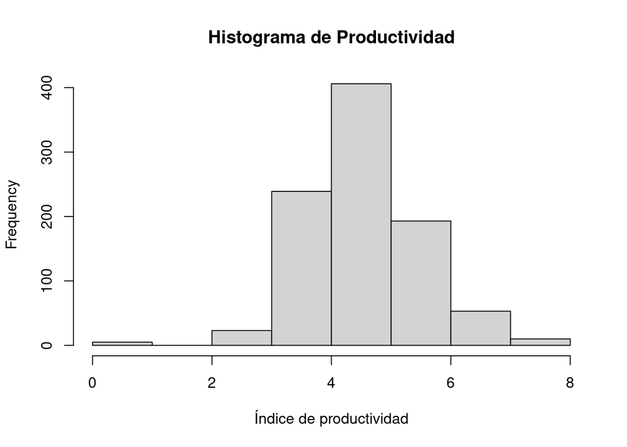

```r
hist(BaseDatosHistorica$Productividad, main = 'Histograma de Productividad', xlab = 'Índice de productividad')
```

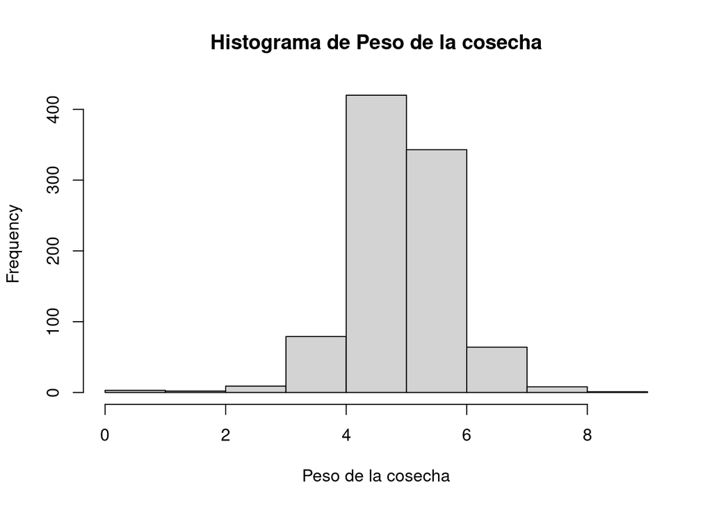

```r
hist(BaseDatosHistorica$`Peso Cosecha wfe`, main = 'Histograma de Peso de la cosecha', xlab = 'Peso de la cosecha')
```

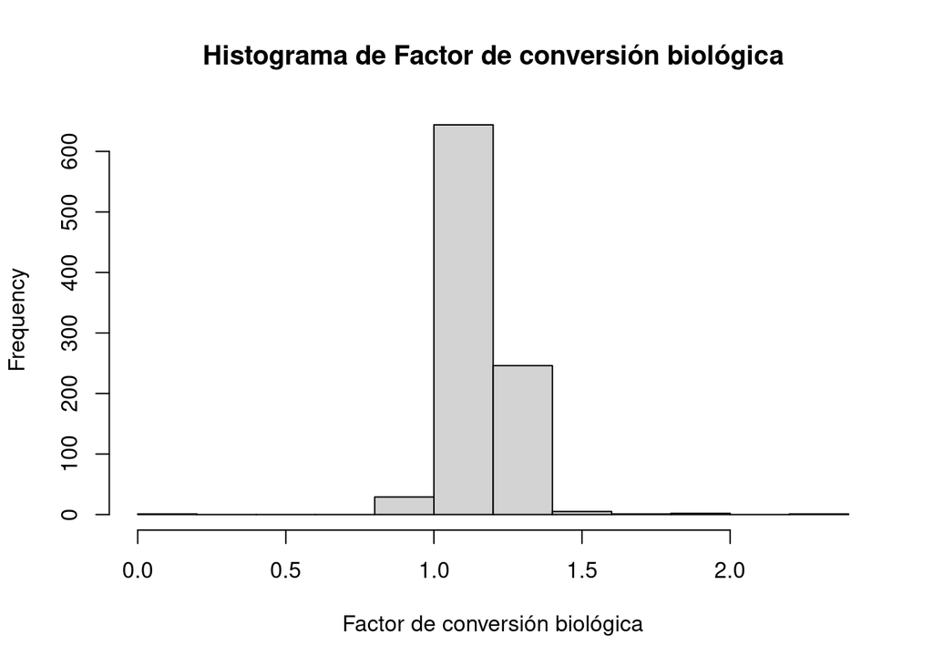

```r
hist(BaseDatosHistorica$FCRb, main = 'Histograma de Factor de conversión biológica', xlab = 'Factor de conversión biológica')
```

### 4. Identifica si los datos están balanceados o no entre tratamientos usando tablas de frecuencia (4 puntos).

```r
categorias <- cut(BaseDatosHistorica$Productividad, breaks = c(0, 4, 5, Inf),
                  labels = c("Bajo", "Normal", "Alto"))
BaseDatosHistorica$Nivel_Productividad <- categorias
table(BaseDatosHistorica$Centro, BaseDatosHistorica$Nivel_Productividad)
```

```
##
##                  Bajo Normal Alto
##   Caicura           1      4   12
##   Canal Bertrand    1      5    8
##   Canalad 1        22      6    0
##   Chivato 1        29     19    8
##   Chivato 2        20      0    0
##   Concheo 2         1     13    4
##   Cordova 1         0      2   11
##   Cordova 2         0      8    8
##   Dring 1          11     21    3
##   Dring 2           3     15    0
##   Dring 3           0     11   25
##   Elena Norte      15      7    0
##   Elena Weste      14      8    0
##   Ester             0     11    1
##   Estero Largo     10      8    2
##   Forsyth           2     23    9
##   Isquiliac         1     11    0
##   Jorge             6     14    0
##   Level 2          17     29   12
##   Marta             1      1   12
##   Midhurst          6     17   17
##   Mina Elena        0      1   15
##   Ninualac 2        3     25   20
##   Orestes          13     14   21
##   Perez de Arce     0     14    0
##   Punta Cola       17     25    2
##   Punta Rouse       3     17   22
##   Punta Vergara     0      0   16
##   SEForsyth         0     17   19
##   Tangbac          15     20    1
##   Victoria         18     15    7
##   Williams 1       35     25    1
```

Interpretación:

La productividad resulta mayormente “alto” en centros como Mina Elena, Marta y Punta Vergara, las cuales tienen la particularidad de ser los primeros centros de cultivo cerrados en la XII Region. Los datos dan cuenta de otros centros pertenecientes a XI Region que presentan datos mayormenente en bajo o normal productividad.

### 5. Establece relación entre variables cuantitativas y factores usando gráficas de correlación, boxplot, interacción o de tamaño de los efectos (4 puntos).

```r
cols = c(20,21,24)

#install.packages("PerformanceAnalytics")
library("PerformanceAnalytics")
```

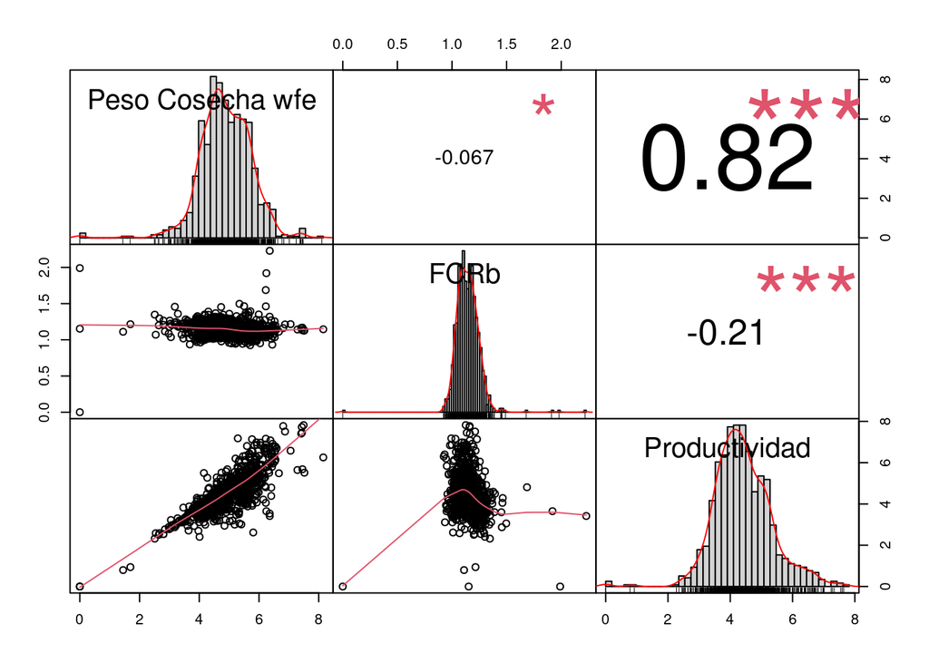

```r
my_data <- BaseDatosHistorica[, c(cols)]
chart.Correlation(my_data, histogram=TRUE, pch=19)
```

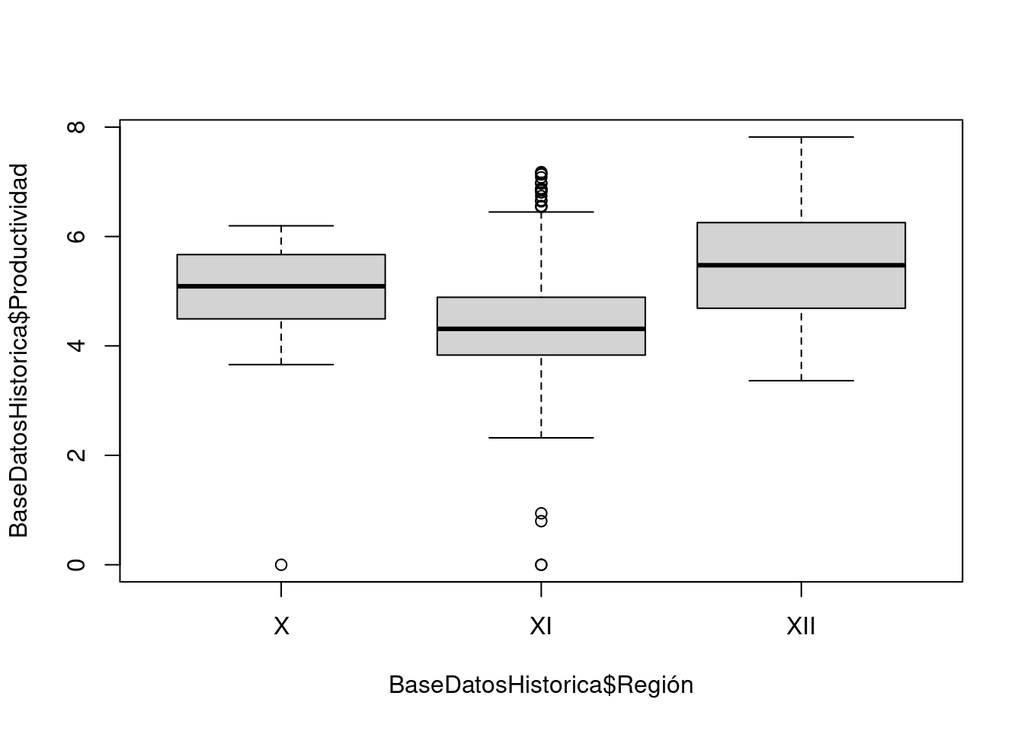

```r
boxplot(BaseDatosHistorica$Productividad ~ BaseDatosHistorica$Región)
```

```r
#install.packages('dplyr')

library(dplyr)
```

```r
X <- filter(BaseDatosHistorica, BaseDatosHistorica$Región == 'X')

XI <- filter(BaseDatosHistorica, BaseDatosHistorica$Región == 'XI')

XII <- filter(BaseDatosHistorica, BaseDatosHistorica$Región == 'XII')
```

```r
print('Correlaciones para la X región')
```

```
## [1] "Correlaciones para la X región"
```

```r
cols = c(20,21,24)
datosX <- X[, c(cols)]
round(cor(datosX), digits = 3)
```

```
##                  Peso Cosecha wfe  FCRb Productividad
## Peso Cosecha wfe            1.000 0.880         0.903
## FCRb                        0.880 1.000         0.669
## Productividad               0.903 0.669         1.000
```

```r
print('Correlaciones para la XI región')
```

```
## [1] "Correlaciones para la XI región"
```

```r
cols = c(20,21,24)
datosX <- XI[, c(cols)]
round(cor(datosX), digits = 3)
```

```
##                  Peso Cosecha wfe   FCRb Productividad
## Peso Cosecha wfe            1.000 -0.168         0.783
## FCRb                       -0.168  1.000        -0.316
## Productividad               0.783 -0.316         1.000
```

```r
print('Correlaciones para la XII región')
```

```
## [1] "Correlaciones para la XII región"
```

```r
cols = c(20,21,24)
datosX <- XII[, c(cols)]
round(cor(datosX), digits = 3)
```

```
##                  Peso Cosecha wfe  FCRb Productividad
## Peso Cosecha wfe            1.000 0.289         0.824
## FCRb                        0.289 1.000         0.219
## Productividad               0.824 0.219         1.000
```

Interpreción:

Interesante analizar la correlación entre variables que globalmente no se correlacionaban pero al analizar por región si se genera una correlación importante, tal como el caso del FCRb y peso cosecha en la X Región, y no en el global presentado anteriormente, aunque hay que considerar que la compañía solo cuenta con un centro de cultivo en X Región, por lo que la muestra es bastante a inferior a otras regiones.

### 6. Identifica si existen errores, datos faltantes o valores atípicos (4 puntos).

```r
contar_outliers <- function(column){

Q1 <- quantile(column, 0.25)
Q3 <- quantile(column, 0.75)
iqr <- IQR(column)

outlier_sup = (iqr * 1.5) + Q3
outlier_inf = Q1 - (iqr * 1.5)

count_sup <- sum(column > outlier_sup)
count_inf <- sum(column < outlier_inf)

total_outliers <- round(count_sup + count_inf,1)
perc_outliers <- round(total_outliers/length(column),3)

salida = c(total_outliers, perc_outliers)
return(salida)

}

print('Proporción de outliers en Productividad X región')
```

```
## [1] "Proporción de outliers en Productividad X región"
```

```r
contar_outliers(X$Productividad)[2]
```

```
## [1] 0.056
```

```r
print('Proporción de outliers en FCRb X región')
```

```
## [1] "Proporción de outliers en FCRb X región"
```

```r
contar_outliers(X$FCRb)[2]
```

```
## [1] 0.056
```

```r
print('Proporción de outliers en Peso Cosecha X región')
```

```
## [1] "Proporción de outliers en Peso Cosecha X región"
```

```r
contar_outliers(X$`Peso Cosecha wfe`)[2]
```

```
## [1] 0.111
```

```r
print('Proporción de outliers en Productividad XI región')
```

```
## [1] "Proporción de outliers en Productividad XI región"
```

```r
contar_outliers(XI$Productividad)[2]
```

```
## [1] 0.026
```

```r
print('Proporción de outliers en FCRb XI región')
```

```
## [1] "Proporción de outliers en FCRb XI región"
```

```r
contar_outliers(XI$FCRb)[2]
```

```
## [1] 0.01
```

```r
print('Proporción de outliers en Peso Cosecha XI región')
```

```
## [1] "Proporción de outliers en Peso Cosecha XI región"
```

```r
contar_outliers(XI$`Peso Cosecha wfe`)[2]
```

```
## [1] 0.012
```

```r
print('Proporción de outliers en Productividad XII región')
```

```
## [1] "Proporción de outliers en Productividad XII región"
```

```r
contar_outliers(XII$Productividad)[2]
```

```
## [1] 0
```

```r
print('Proporción de outliers en FCRb XII región')
```

```
## [1] "Proporción de outliers en FCRb XII región"
```

```r
contar_outliers(XII$FCRb)[2]
```

```
## [1] 0.019
```

```r
print('Proporción de outliers en Peso Cosecha XII región')
```

```
## [1] "Proporción de outliers en Peso Cosecha XII región"
```

```r
contar_outliers(XII$`Peso Cosecha wfe`)[2]
```

```
## [1] 0.01
```

```r
#install.packages('psych')
library(psych)
psych::describe(BaseDatosHistorica[,cols], quant=c(.25,.75), IQR = TRUE, omit = TRUE)
```

```
##                  vars   n mean   sd median trimmed  mad min  max range  skew
## Peso Cosecha wfe    1 929 4.92 0.85   4.88    4.92 0.82   0 8.15  8.15 -0.57
## FCRb                2 929 1.15 0.11   1.14    1.14 0.09   0 2.23  2.23  0.90
## Productividad       3 929 4.51 0.94   4.45    4.47 0.84   0 7.82  7.82  0.14
##                  kurtosis   se  IQR Q0.25 Q0.75
## Peso Cosecha wfe     3.78 0.03 1.10  4.41  5.52
## FCRb                27.55 0.00 0.13  1.08  1.21
## Productividad        2.18 0.03 1.16  3.91  5.07
```